# Repeated Measures ANOVA

André Meichtry

```r
library(lme4)
library(lmerTest)
library(psych)
library(ggplot2)
```

# 1 Repeated measures ANOVA

## 1.1 Model AMT (11.4.1)

Repeated Measures ANOVA with **one within-subject factor**.

$Y_{ij}=\mu+\alpha_j+\pi_i+\epsilon_{ij},\quad i=1,...,n;\quad j=1,...,I.$

- $\pi_i$ are subjects effects, they could be considered **fixed**, but most often, we will treat them as **random effects**, that is
- $\pi_i \sim N(0,\nu^2)$ are **random intercepts** with **between-subject** variance $\nu^2$
- $\epsilon_{ij}\sim N(0,\tau^2)$ with **within-subject** variance $\tau^2$
- within-subject correlation $\rho=Cor(Y_{ij},Y_{ik})=\frac{\nu^2}{\nu^2+\tau^2}$ for $j\neq k$.
- $\sigma^2=\nu^2+\tau^2$
- This model is called a **Linear Mixed Model (LMM)**. In contrast to linear models, they have **additional random part** to model the **within-subject correlation**. $\rho$ is called the **intra-class correlation**.
- The advantage of treating the $\pi_i$ as random is that
  - we need less parameters (one between-subject variance $\nu^2$ instead of $n$ parameters $\pi_i$)
  - Fixed-effects parameters do not have interpretation as population parameters.

## 1.2 Within-subject factor with 2 levels

The simplest Repeated Measures ANOVA is the **paired $t$-test** with $I=2$

### 1.2.1 Example data

The data.frame `d.long2` consists of time points 1 and 2.

```r
headTail(d.long2)
```

```
    subject time response
1        s1   t1    22.93
2        s1   t2    38.43
3        s2   t1     10.8
4        s2   t2    18.17
...    <NA> <NA>      ...
57      s29   t1     6.53
58      s29   t2    16.07
59      s30   t1    34.25
60      s30   t2     42.4
```

```r
aggregate(response~time,data=d.long2,summary)
```

```
  time response.Min. response.1st Qu. response.Median response.Mean response.3rd Qu. response.Max.
1   t1          6.53            17.65           23.27         24.73            33.67         41.39
2   t2          9.75            32.23           36.44         34.89            40.37         52.98
```

```r
describeBy(d.long2$response,group=d.long2$time,mat=TRUE,skew=FALSE)
```

```
    item group1 vars  n mean   sd  min  max range   se
X11    1     t1    1 30 24.7 9.15 6.53 41.4  34.9 1.67
X12    2     t2    1 30 34.9 9.25 9.75 53.0  43.2 1.69
```

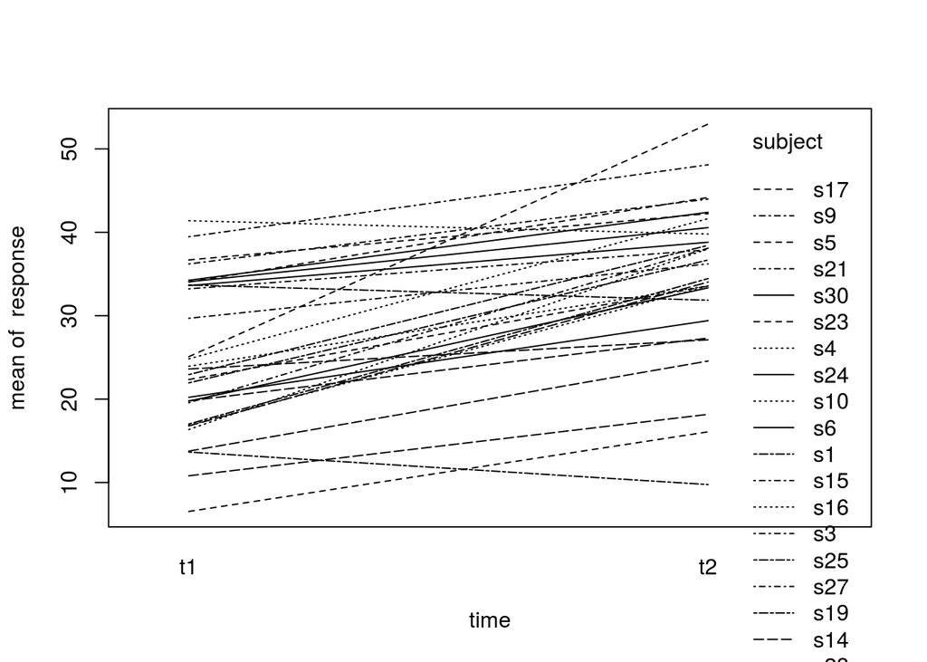

```r
with(d.long2,interaction.plot(time,subject,response))
```

A popular package for plotting is the **ggplot2** package:

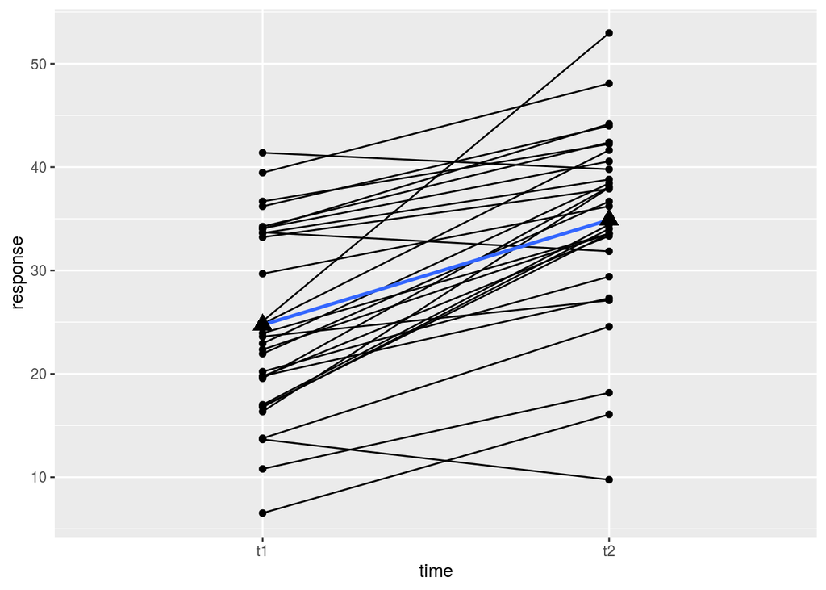

```r
p <- ggplot(data = d.long2, aes(x = time, y = response, group = subject))
p <- p+geom_point()+geom_line()+stat_smooth(aes(group = 1),method="lm",se=FALSE)
p <- p + stat_summary(aes(group=1), geom = "point", fun.y = mean,shape = 17, size = 4)
p
```

### 1.2.2 As paired $t$-Test

```r
t.test(response~time,paired=TRUE,data=d.long2)
```

```
    Paired t-test

data:  response by time
t = -8, df = 29, p-value = 9e-09
alternative hypothesis: true difference in means is not equal to 0
95 percent confidence interval:
 -12.77  -7.54
sample estimates:
mean of the differences
                  -10.2
```

```r
cor(d.long2$response[d.long2$time=="t1"],d.long2$response[d.long2$time=="t2"])
```

```
[1] 0.71
```

### 1.2.3 As one-sample $t$-Test changes

```r
x<-d.long2$response[d.long2$time=="t1"]
y<-d.long2$response[d.long2$time=="t2"]
t.test(y-x)
```

```
    One Sample t-test

data:  y - x
t = 8, df = 29, p-value = 9e-09
alternative hypothesis: true mean is not equal to 0
95 percent confidence interval:
  7.54 12.77
sample estimates:
mean of x
     10.2
```

### 1.2.4 Observed correlation

```r
cor(x,y)
```

```
[1] 0.71
```

### 1.2.5 As ANOVA

**aov()** provides a wrapper to **lm()** for fitting linear models. The main difference from lm is in the way print, summary and so on handle the fit: this is expressed in the traditional language of the analysis of variance rather than that of linear models. If the formula contains a single Error term, this is used to specify error strata, and appropriate models are fitted within each error stratum.

```r
modelRep1<-aov(response~time+Error(subject),data=d.long2)
print(summary(modelRep1),digits=4)
```

```
Error: subject
          Df Sum Sq Mean Sq F value Pr(>F)
Residuals 29   4197   144.7

Error: Within
          Df Sum Sq Mean Sq F value  Pr(>F)
time       1 1547.6  1547.6      63 9.4e-09
Residuals 29  712.4    24.6
```

### 1.2.6 Repeat Sum of Squares…

Let us repeat the concept of **sum of squares** and reproduce the results above.

#### 1.2.6.1 Model fits

```r
mod0 <- lm(response~1,d.long2)
mods <- lm(response~subject,d.long2)
modt <- lm(response~time,d.long2)
modts <-lm(response~subject+time,d.long2)
```

#### 1.2.6.2 Residual sum of squares

```r
rss.0 <- sum((mod0$residuals)^2)
#(ss.0<-sum((d.long2$response-mod0$fitted)^2)) ##equivalent...
rss.s <- sum((mods$residuals)^2)
rss.t <- sum((modt$residuals)^2)
rss.ts<- sum((modts$residuals)^2)
```

#### 1.2.6.3 Explained Sum of Squares

```r
rss.0
```

```
[1] 6457
```

```r
rss.0-rss.s
```

```
[1] 4197
```

```r
rss.0-rss.t
```

```
[1] 1548
```

```r
rss.0-rss.ts
```

```
[1] 5744
```

```r
rss.ts
```

```
[1] 712
```

### 1.2.7 As Linear Mixed Model (LMM)

LMM are an alternative for the analysis of repeated measurements for unbalanced data or data with missing values. We will come back to LMM later. We use the **lmer()** function of the package **lme4** and **lmerTest**. LMM are fitted using **Maximum Likelihood Estimation** (in contrast to **lm()** and **aov()** which are fitted using **Least Squares**).

The syntax for the model is

```r
lmm1<-lmer(response~time+(1|subject), data=d.long2)
summary(lmm1,cor=FALSE)
```

```
Linear mixed model fit by REML. t-tests use Satterthwaite's method ['lmerModLmerTest']
Formula: response ~ time + (1 | subject)
   Data: d.long2

REML criterion at convergence: 408

Scaled residuals:
    Min      1Q  Median      3Q     Max
-2.0380 -0.4876 -0.0289  0.5657  2.1045

Random effects:
 Groups   Name        Variance Std.Dev.
 subject  (Intercept) 60.1     7.75
 Residual             24.6     4.96
Number of obs: 60, groups:  subject, 30

Fixed effects:
            Estimate Std. Error    df t value Pr(>|t|)
(Intercept)    24.73       1.68 38.57   14.73  < 2e-16
timet2         10.16       1.28 29.00    7.94  9.4e-09
```

The estimate of the intraclass correlation $\nu^2/\sigma^2$ is

```
[1] 0.71
```

```r
anova(lmm1)
```

```
Type III Analysis of Variance Table with Satterthwaite's method
     Sum Sq Mean Sq NumDF DenDF F value  Pr(>F)
time   1548    1548     1    29      63 9.4e-09
```

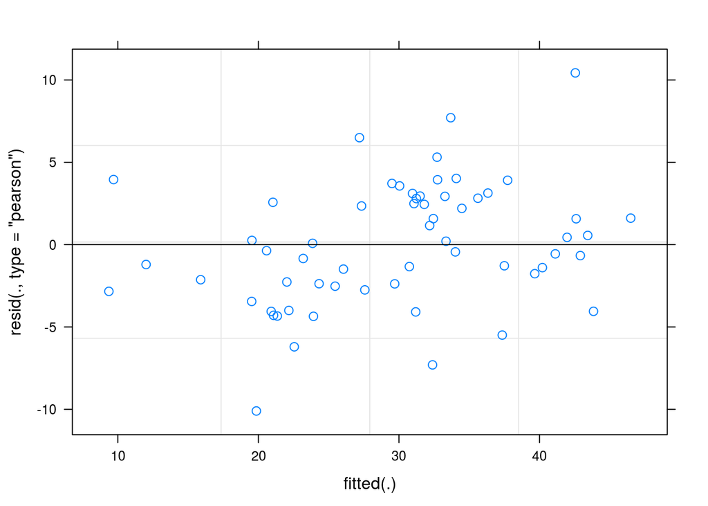

```r
plot(lmm1)
```

## 1.3 Arbitrary number of levels

### 1.3.1 Example data

The within-subject factor time now has $I=4$ levels:

```r
headTail(d.long,7,7)
```

```
    subject time response
1        s1   t1    18.85
2        s1   t2    21.05
3        s1   t3    24.77
4        s1   t4    28.35
5        s2   t1    24.43
6        s2   t2    13.59
7        s2   t3    14.81
...    <NA> <NA>      ...
194     s49   t2    31.66
195     s49   t3    26.08
196     s49   t4     37.1
197     s50   t1     2.33
198     s50   t2     4.81
199     s50   t3     7.37
200     s50   t4     8.75
```

```r
aggregate(response~time,data=d.long,summary)
```

```
  time response.Min. response.1st Qu. response.Median response.Mean response.3rd Qu. response.Max.
1   t1         1.514           14.577          23.090        21.755           29.467        40.798
2   t2        -0.935           18.085          23.107        24.454           33.429        42.803
3   t3         7.371           19.054          26.458        25.748           32.032        42.612
4   t4        -0.073           18.473          27.236        25.510           34.115        47.778
```

```r
describeBy(d.long$response,group=d.long$time,mat=TRUE,skew=FALSE)
```

```
    item group1 vars  n mean    sd    min  max range   se
X11    1     t1    1 50 21.8 10.02  1.514 40.8  39.3 1.42
X12    2     t2    1 50 24.5 10.85 -0.935 42.8  43.7 1.54
X13    3     t3    1 50 25.7  8.69  7.371 42.6  35.2 1.23
X14    4     t4    1 50 25.5 10.85 -0.073 47.8  47.9 1.53
```

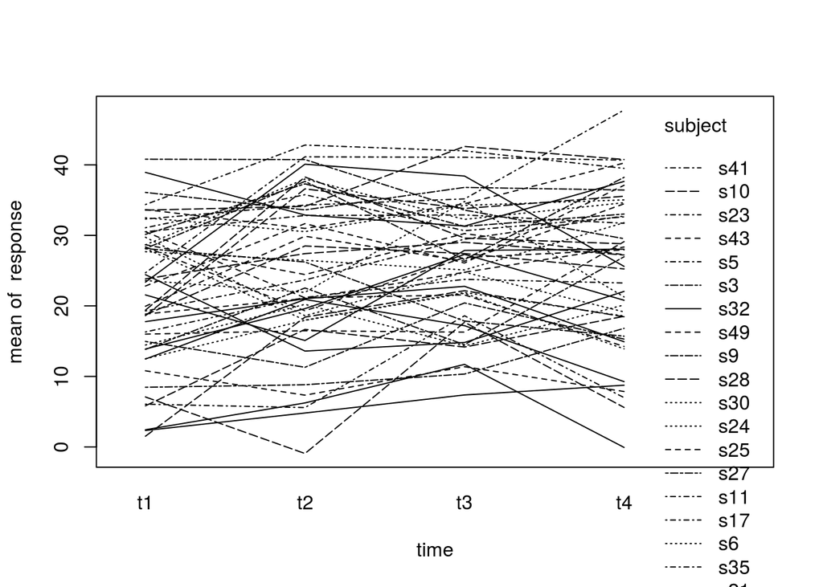

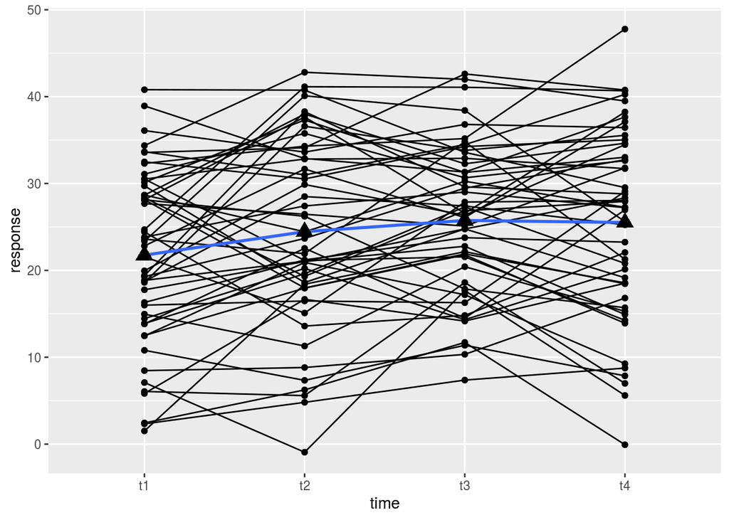

```r
with(d.long,interaction.plot(time,subject,response))
p <- ggplot(data = d.long, aes(x = time, y = response, group = subject))
p <- p+geom_point()+geom_line()+stat_smooth(aes(group = 1),se=FALSE)
p <- p + stat_summary(aes(group=1), geom = "point", fun.y = mean,shape = 17, size = 4)
p
```

### 1.3.2 As ANOVA

```r
modelRep2 <-aov(response~time+Error(subject),data=d.long)
summary(modelRep2)
```

```
Error: subject
          Df Sum Sq Mean Sq F value Pr(>F)
Residuals 49  16491     337

Error: Within
           Df Sum Sq Mean Sq F value  Pr(>F)
time        3    502     167    6.71 0.00028
Residuals 147   3669      25
```

### 1.3.3 As LMM

```r
lmm2 <- lmer(response~time+(1|subject),data=d.long)
summary(lmm2,cor=FALSE)
```

```
Linear mixed model fit by REML. t-tests use Satterthwaite's method ['lmerModLmerTest']
Formula: response ~ time + (1 | subject)
   Data: d.long

REML criterion at convergence: 1330

Scaled residuals:
    Min      1Q  Median      3Q     Max
-2.3401 -0.6134 -0.0499  0.5716  2.2168

Random effects:
 Groups   Name        Variance Std.Dev.
 subject  (Intercept) 77.9     8.83
 Residual             25.0     5.00
Number of obs: 200, groups:  subject, 50

Fixed effects:
            Estimate Std. Error      df t value Pr(>|t|)
(Intercept)   21.755      1.434  72.041   15.17  < 2e-16
timet2         2.699      0.999 147.000    2.70  0.00771
timet3         3.993      0.999 147.000    4.00  0.00010
timet4         3.755      0.999 147.000    3.76  0.00025
```

```r
anova(lmm2)
```

```
Type III Analysis of Variance Table with Satterthwaite's method
     Sum Sq Mean Sq NumDF DenDF F value  Pr(>F)
time    502     167     3   147    6.71 0.00028
```

The estimate of the intraclass correlation $\nu^2/\sigma^2$ is

```
[1] 0.757
```

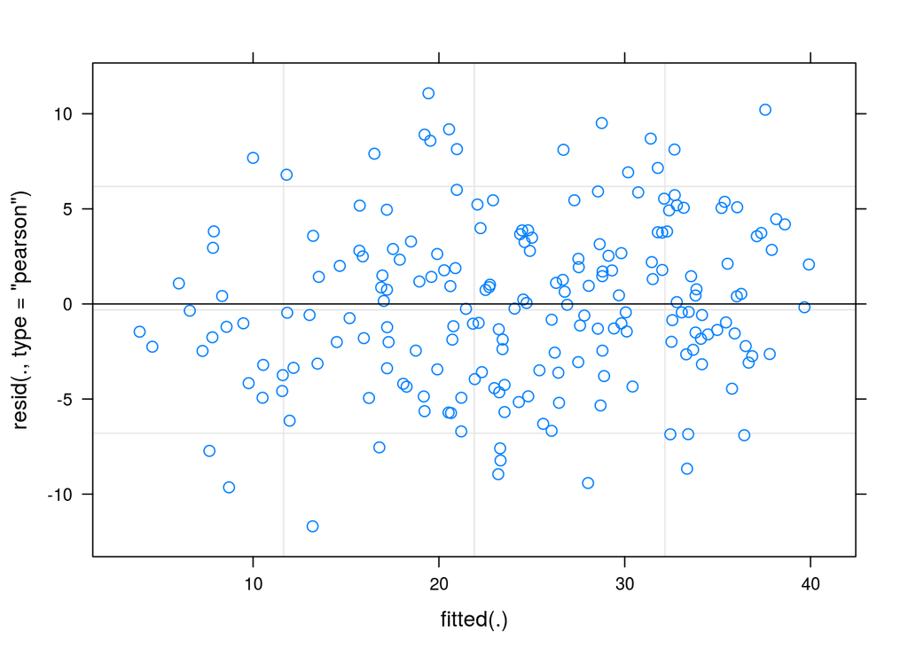

```r
plot(lmm2)
```

## 1.4 Within- and between-subject factor

A frequent question is the changes of 2 groups from Pre to Post. This corresponds to a model with one **within-subject factor time** and one **between-subject factor group**:

$Y_{ijk}=\mu+\alpha_j\times\beta_k+\pi_i+\epsilon_{ijk},\quad i=1,...,n\quad k=1,2\quad j=1,2.$ with

- $\alpha_j$ as time effects
- $\beta_k$ as group effects
- $\alpha_j:\beta_k$ as interaction effects. (=difference in slopes, effect of one predictor depends on the value on the other predictor.)

### 1.4.1 Example data

```r
headTail(d.longB)
```

```
    subject time group response
1        s1   t1   Ctr    91.66
2        s1   t2   Ctr    85.83
3        s2   t1   Ctr    95.41
4        s2   t2   Ctr    92.69
...    <NA> <NA>  <NA>      ...
197     s99   t1   Trt   100.59
198     s99   t2   Trt   109.22
199    s100   t1   Trt    99.32
200    s100   t2   Trt   111.25
```

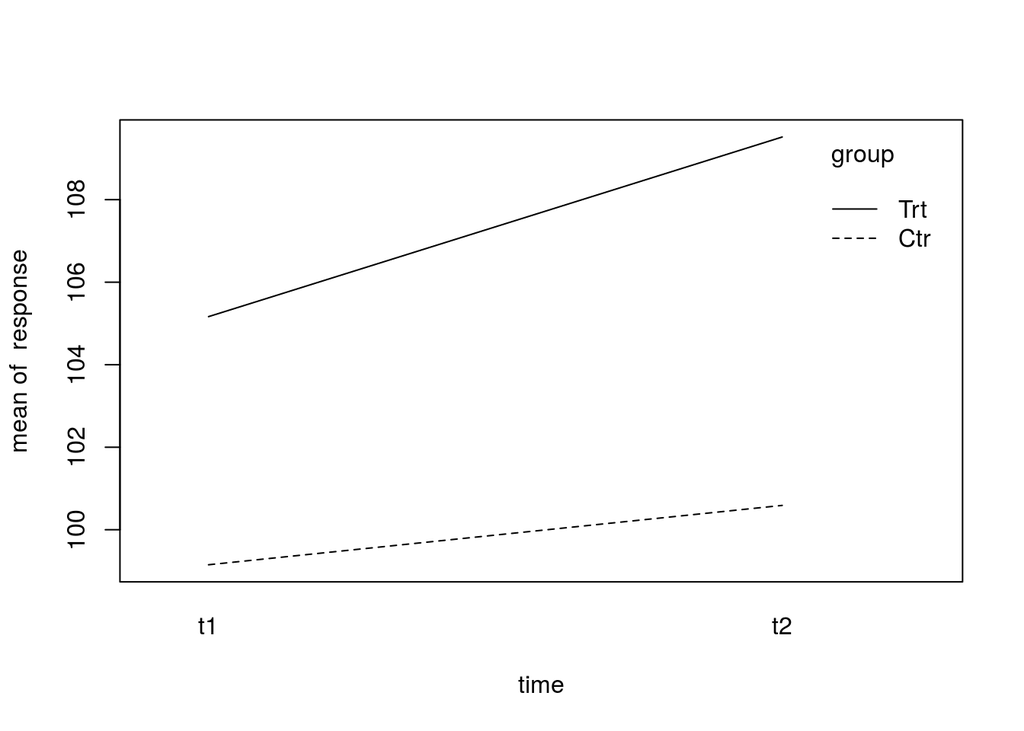

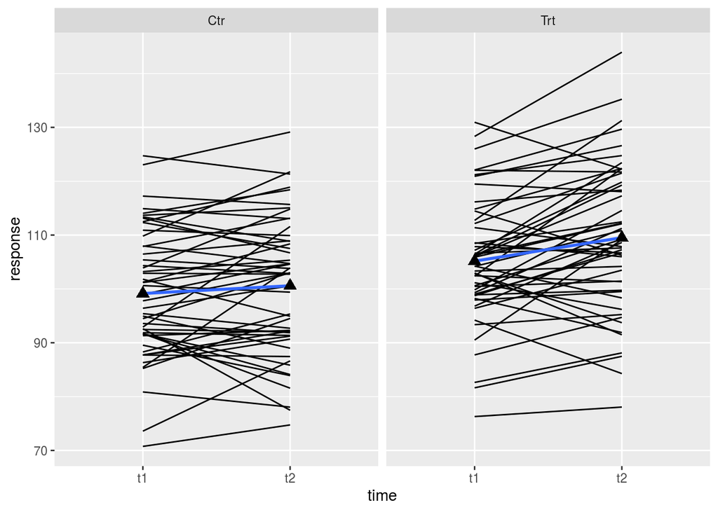

```r
with(d.longB,interaction.plot(time,group,response))
## with(d.longB,interaction.plot(time,subject,response))
p <- ggplot(data = d.longB, aes(x = time, y = response, group = subject))
p <- p + geom_line() + facet_grid(. ~ group)
p <- p + stat_smooth(aes(group = 1), method = "lm", se = FALSE) + stat_summary(aes(group = 1), geom = "point", fun.y = mean, shape = 17, size = 3)
p
```

```r
aggregate(response~time+group,data=d.longB,summary)
```

```
  time group response.Min. response.1st Qu. response.Median response.Mean response.3rd Qu. response.Max.
1   t1   Ctr          70.8             91.6            98.4          99.2            108.0         124.7
2   t2   Ctr          74.7             91.5           102.9         100.6            108.9         129.1
3   t1   Trt          76.3             98.9           104.2         105.2            112.0         130.9
4   t2   Trt          78.1            100.1           108.9         109.5            119.7         144.0
```

```r
describeBy(d.longB$response,group=list(d.longB$time,d.longB$group),mat=TRUE,skew=FALSE)
```

```
    item group1 group2 vars  n  mean   sd  min max range   se
X11    1     t1    Ctr    1 50  99.2 12.0 70.8 125  54.0 1.69
X12    2     t2    Ctr    1 50 100.6 12.8 74.7 129  54.4 1.80
X13    3     t1    Trt    1 50 105.2 11.6 76.3 131  54.6 1.64
X14    4     t2    Trt    1 50 109.5 13.8 78.1 144  65.9 1.95
```

```r
tableone::CreateTableOne(vars="response",strata=c("group","time"),data=d.longB,test=FALSE)
```

```
                      Stratified by group:time
                       Ctr:t1        Trt:t1         Ctr:t2         Trt:t2
  n                       50             50             50             50
  response (mean (SD)) 99.15 (11.97) 105.17 (11.60) 100.59 (12.75) 109.52 (13.79)
```

### 1.4.2 As ANOVA

```r
modelRep3 <-aov(response~time*group+Error(subject/time),data=d.longB) ##+Error(subject) is equivalent
print(summary(modelRep3),digits=4)
```

```
Error: subject
          Df Sum Sq Mean Sq F value  Pr(>F)
group      1   2791  2791.3   9.684 0.00244
Residuals 98  28246   288.2

Error: subject:time
           Df Sum Sq Mean Sq F value   Pr(>F)
time        1  419.4   419.4  15.446 0.000158
time:group  1  106.2   106.2   3.912 0.050754
Residuals  98 2661.2    27.2
```

### 1.4.3 As LMM

```r
lmm3 <- lmer(response~time*group+(1|subject),data=d.longB)
summary(lmm3,cor=FALSE)
```

```
Linear mixed model fit by REML. t-tests use Satterthwaite's method ['lmerModLmerTest']
Formula: response ~ time * group + (1 | subject)
   Data: d.longB

REML criterion at convergence: 1450

Scaled residuals:
    Min      1Q  Median      3Q     Max
-1.8588 -0.4692  0.0127  0.5366  1.6971

Random effects:
 Groups   Name        Variance Std.Dev.
 subject  (Intercept) 130.5    11.43
 Residual              27.2     5.21
Number of obs: 200, groups:  subject, 100

Fixed effects:
                Estimate Std. Error     df t value Pr(>|t|)
(Intercept)        99.15       1.78 116.30   55.83   <2e-16
timet2              1.44       1.04  98.00    1.38    0.171
groupTrt            6.01       2.51 116.30    2.39    0.018
timet2:groupTrt     2.92       1.47  98.00    1.98    0.051
```

```r
anova(lmm3)
```

```
Type III Analysis of Variance Table with Satterthwaite's method
           Sum Sq Mean Sq NumDF DenDF F value  Pr(>F)
time          419     419     1    98   15.45 0.00016
group         263     263     1    98    9.68 0.00244
time:group    106     106     1    98    3.91 0.05075
```

The estimate of the intraclass correlation $\nu^2/\sigma^2$ is

```
[1] 0.828
```

### 1.4.4 Fitted model*

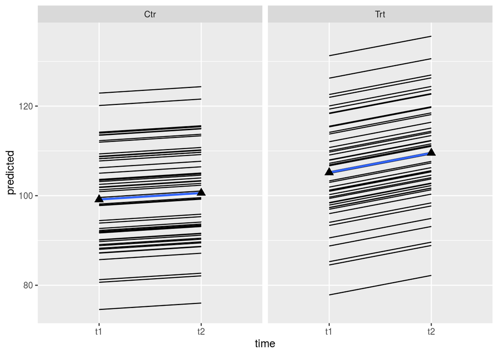

```r
predicted<-predict(lmm3)
p <- ggplot(data = d.longB, aes(x = time, y = predicted, group = subject))
p <- p + geom_line() + facet_grid(. ~ group)
p <- p + stat_smooth(aes(group = 1), method = "lm", se = FALSE) + stat_summary(aes(group = 1), geom = "point", fun.y = mean, shape = 17, size = 3)
p
```

### 1.4.5 Residual analysis

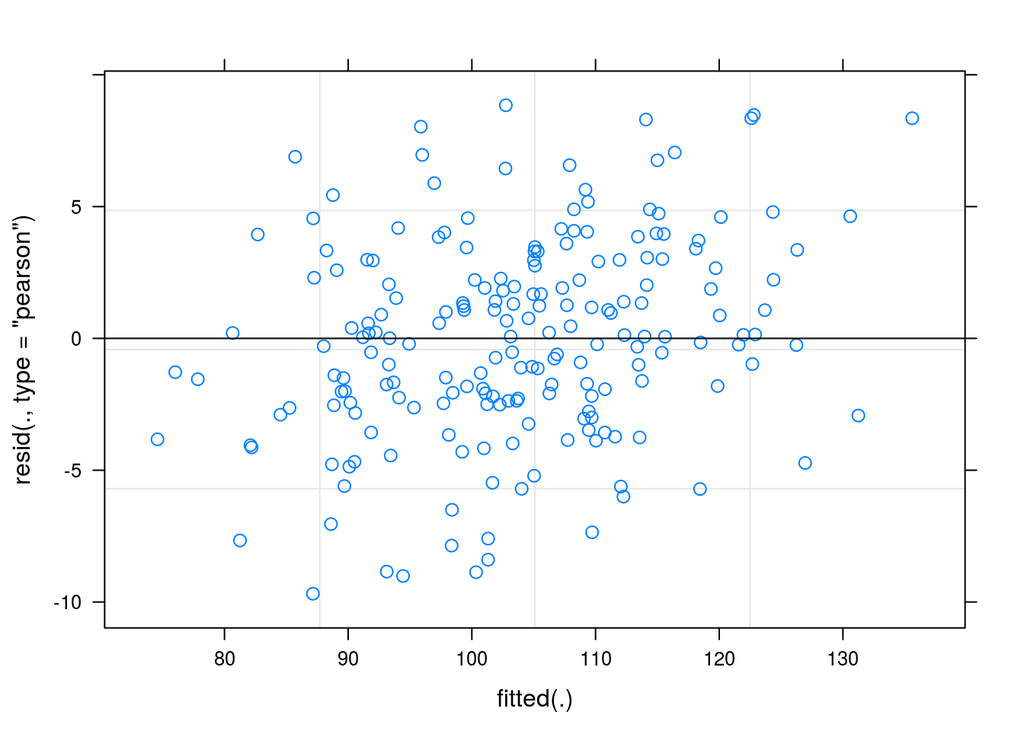

```r
plot(lmm3)
```